# Test - AB provost site Normal

Steffi LaZerte

August 24, 2017

# Details

6.76 min to run

#### Original Dem (Relief)

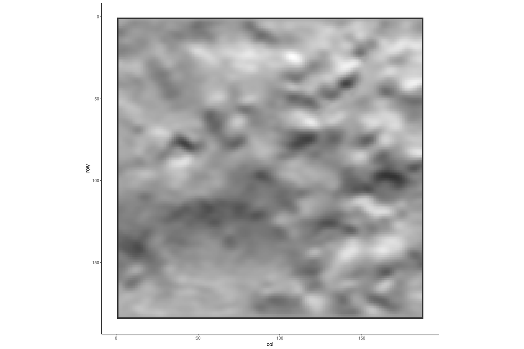

#### Original Dem (Elevation)

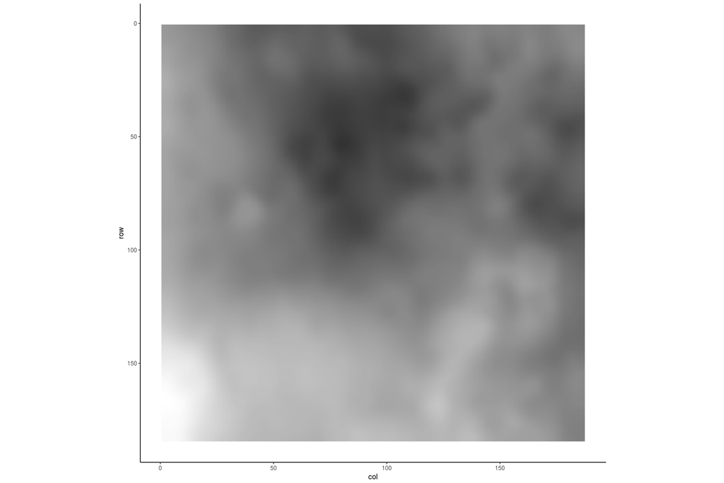

# Visual Comparison

## Original vs. New Local Shed assignment

- These are the local sheds (shedno) after amalgamating the small ones
- Sheds are identical

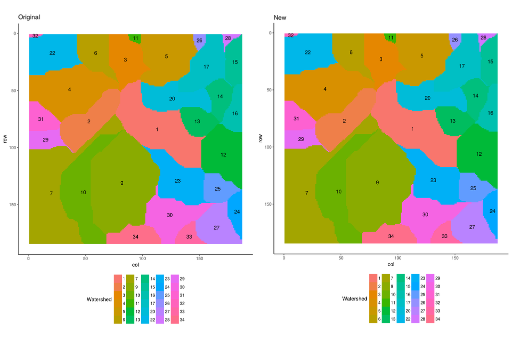

## Original vs. New Pond Shed assignment

- These are the pond sheds, which reflect how sheds combined during the second pit removal process
- Sheds are identical, except that some numbered differently

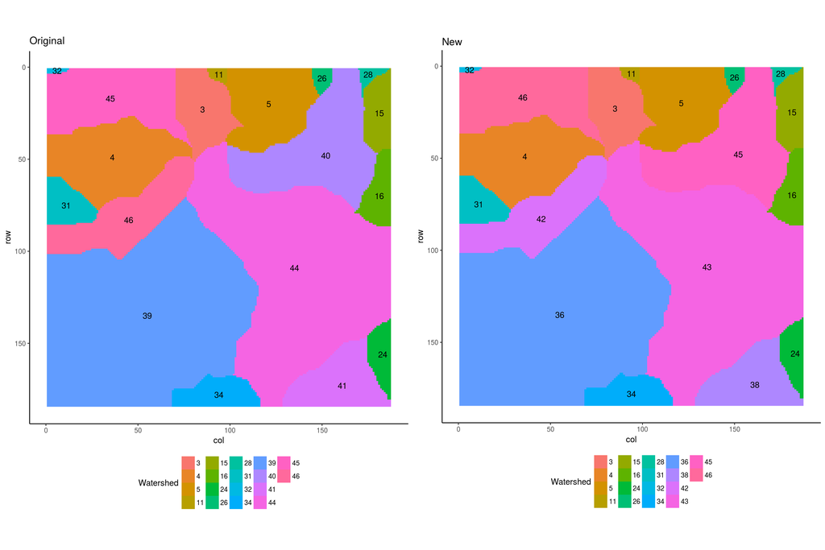

# Numeric Comparison

## Compare pond stats

We know the watersheds have different numbering, so first need to renumber all to match

```r
pond <- shedno_update2(pond) %>% arrange(shedno)
orig_pond <- shedno_update2(orig_pond) %>% arrange(shedno)
```

**Original Pond data**

|  | shedno | pour_elev | shed_area | pit_area | pit_vol | pit_elev | varatio | pit_seqno | pit_row | pit_col | out_elev | out_row | out_col | in_row | in_col | out_seqno | in_seqno | next_pit | edge | final | becomes | out_shed |
| --- | --- | --- | --- | --- | --- | --- | --- | --- | --- | --- | --- | --- | --- | --- | --- | --- | --- | --- | --- | --- | --- | --- |
| 1 | 1 | 670.724 | 9293 | 2872 | 4721.135 | 665.34 | 508.03 | 30669 | 165 | 1 | 670.724 | 175 | 77 | 174 | 77 | 32615 | 32428 | 34 | True | True | 0 | 11 |
| 2 | 2 | 670.514 | 5309 | 2108 | 4167.741 | 665.34 | 785.03 | 30669 | 165 | 1 | 670.512 | 155 | 57 | 155 | 56 | 28855 | 28854 | 36 | True | False | 1 | 12 |
| 3 | 3 | 670.132 | 3287 | 1483 | 3441.443 | 665.34 | 1046.99 | 30669 | 165 | 1 | 670.132 | 162 | 37 | 163 | 36 | 30144 | 30330 | 35 | True | False | 2 | 4 |
| 4 | 4 | 670.132 | 2022 | 110 | 9.085 | 669.936 | 4.49 | 29024 | 156 | 39 | 670.125 | 163 | 36 | 162 | 37 | 30330 | 30144 | 7 | False | False | 2 | 3 |
| 5 | 5 | 671.046 | 8306 | 250 | 94.104 | 669.989 | 11.33 | 31538 | 169 | 122 | 671.041 | 184 | 129 | 184 | 128 | 34350 | 34349 | 38 | True | True | 0 | 13 |
| 6 | 6 | 671.046 | 7669 | 250 | 94.104 | 669.989 | 12.27 | 31538 | 169 | 122 | 671.041 | 184 | 129 | 184 | 128 | 34350 | 34349 | 38 | True | True | 5 | 13 |
| 7 | 7 | 671.046 | 7072 | 250 | 94.104 | 669.989 | 13.31 | 31538 | 169 | 122 | 671.041 | 184 | 129 | 184 | 128 | 34350 | 34349 | 38 | True | True | 6 | 13 |
| 8 | 8 | 671.046 | 5566 | 250 | 94.104 | 669.989 | 16.91 | 31538 | 169 | 122 | 671.041 | 184 | 129 | 184 | 128 | 34350 | 34349 | 38 | True | True | 7 | 13 |
| 9 | 9 | 671.046 | 2867 | 250 | 94.104 | 669.989 | 32.82 | 31538 | 169 | 122 | 671.041 | 184 | 129 | 184 | 128 | 34350 | 34349 | 38 | True | True | 8 | 14 |
| 10 | 10 | 671.046 | 1377 | 250 | 94.104 | 669.989 | 68.34 | 31538 | 169 | 122 | 671.041 | 184 | 129 | 184 | 128 | 34350 | 34349 | 38 | True | True | 9 | 14 |

[output cut: 32 more lines]

**New Pond data**

|  | shedno | pour_elev | shed_area | pit_area | pit_vol | pit_elev | varatio | pit_seqno | pit_row | pit_col | out_elev | out_row | out_col | in_row | in_col | out_seqno | in_seqno | next_pit | final | becomes | out_shed |
| --- | --- | --- | --- | --- | --- | --- | --- | --- | --- | --- | --- | --- | --- | --- | --- | --- | --- | --- | --- | --- | --- |
| 1 | 1 | 670.724 | 9293 | 2873 | 4721.136 | 665.34 | 508.03 | 30482 | 164 | 1 | 670.724 | 175 | 77 | 174 | 77 | 32615 | 32428 | 34 | True | 0 | 11 |
| 2 | 2 | 670.514 | 5309 | 2109 | 4167.741 | 665.34 | 785.03 | 30482 | 164 | 1 | 670.512 | 154 | 57 | 155 | 56 | 28668 | 28854 | 9 | False | 1 | 12 |
| 3 | 3 | 670.132 | 3287 | 1483 | 3441.443 | 665.34 | 1046.99 | 30482 | 164 | 1 | 670.132 | 162 | 37 | 163 | 36 | 30144 | 30330 | 10 | False | 2 | 4 |
| 4 | 4 | 670.132 | 2022 | 110 | 9.085 | 669.936 | 4.49 | 29024 | 156 | 39 | 670.125 | 163 | 36 | 162 | 37 | 30330 | 30144 | 7 | False | 2 | 3 |
| 5 | 5 | 671.046 | 8306 | 250 | 94.104 | 669.989 | 11.33 | 31538 | 169 | 122 | 671.041 | 184 | 129 | 184 | 128 | 34350 | 34349 | 38 | True | 0 | 13 |
| 6 | 6 | 671.046 | 7669 | 250 | 94.104 | 669.989 | 12.27 | 31538 | 169 | 122 | 671.041 | 184 | 129 | 184 | 128 | 34350 | 34349 | 38 | True | 5 | 13 |
| 7 | 7 | 671.046 | 7072 | 250 | 94.104 | 669.989 | 13.31 | 31538 | 169 | 122 | 671.041 | 184 | 129 | 184 | 128 | 34350 | 34349 | 38 | True | 6 | 13 |
| 8 | 8 | 671.046 | 5566 | 250 | 94.104 | 669.989 | 16.91 | 31538 | 169 | 122 | 671.041 | 184 | 129 | 184 | 128 | 34350 | 34349 | 38 | True | 7 | 13 |
| 9 | 9 | 671.046 | 2867 | 250 | 94.104 | 669.989 | 32.82 | 31538 | 169 | 122 | 671.041 | 184 | 129 | 184 | 128 | 34350 | 34349 | 33 | True | 8 | 14 |
| 10 | 10 | 671.046 | 1377 | 250 | 94.104 | 669.989 | 68.34 | 31538 | 169 | 122 | 671.041 | 184 | 129 | 184 | 128 | 34350 | 34349 | 33 | True | 9 | 14 |

[output cut: 32 more lines]

**Differences**

```r
c <- compare(pond, orig_pond)
```

```
## Pit area not the same, but within 3 cells
```

```
## Pit Vol not the same, but within 1
```

```
## Varatio not the same, but within 5
```

```
## Pit seqno not all the same, but all within 1 cell
```

```
## Out elev not all the same, but within 0.01
```

```
## Out seqno not all the same, but all within 1 cell
```

```
## In seqno not all the same, but all within 1 cell
```

```
## Not all next_pit the same
```

- All important values (pit area, pit vol, varatio, becomes) are identical, or only different by a small degree
- Nextpit is often incorrect (not sure why)
- Exact location of pourpoint between two watersheds is sometimes off by a cell or two (out seqno and in seqno)
- Exact location of center pit cell is sometimes off by a cell or two, for example:

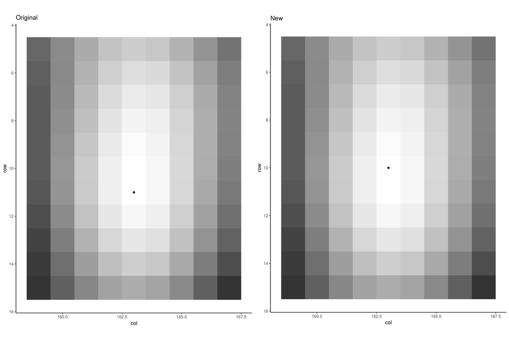

## Compare fill stats

We know the watersheds have different numbering, so first need to renumber all to match

```r
fill <- shedno_update2(fill)
orig_fill <- shedno_update2(orig_fill)
```

**Original Fill data**

|  | shedno | pour_elev | shed_area | pit_area | pit_vol | pit_elev | varatio | pit_seqno | pit_row | pit_col | out_elev | out_row | out_col | in_row | in_col | out_seqno | in_seqno | edge_pit | next_pit | removed | stage | final | becomes | out_shed | end_pit |
| --- | --- | --- | --- | --- | --- | --- | --- | --- | --- | --- | --- | --- | --- | --- | --- | --- | --- | --- | --- | --- | --- | --- | --- | --- | --- |
| 1 | 24 | 673.072 | 2699 | 32 | 2.44 | 672.899 | 0.9 | 20900 | 112 | 143 | 673.071 | 118 | 143 | 117 | 142 | 22022 | 21834 | False | 23 | True | 1 | False | 14 | 15 | 6 |
| 2 | 15 | 671.287 | 1490 | 73 | 6.091 | 671.127 | 4.09 | 25942 | 139 | 136 | 671.287 | 147 | 132 | 146 | 132 | 27434 | 27247 | False | 30 | True | 1 | False | 14 | 9 | 6 |
| 3 | 9 | 671.046 | 1377 | 250 | 94.104 | 669.989 | 68.34 | 31538 | 169 | 122 | 671.041 | 184 | 129 | 184 | 128 | 34350 | 34349 | True | 33 | True | 1 | False | 8 | 13 | 6 |
| 4 | 14 | 671.287 | 4189 | 73 | 6.091 | 671.127 | 1.45 | 25942 | 139 | 136 | 671.287 | 147 | 132 | 146 | 132 | 27434 | 27247 | False | 30 | True | 0 | False | 8 | 9 | 6 |
| 5 | 37 | 676.232 | 1171 | 62 | 3.626 | 676.113 | 3.1 | 10621 | 57 | 149 | 676.232 | 51 | 144 | 52 | 145 | 9494 | 9682 | False | 17 | True | 1 | False | 32 | 33 | 16 |
| 6 | 33 | 675.264 | 1296 | 137 | 31.315 | 674.74 | 24.16 | 2033 | 11 | 163 | 675.263 | 1 | 155 | 1 | 156 | 155 | 156 | True | 26 | True | 1 | False | 32 | 35 | 16 |
| 7 | 11 | 670.514 | 3984 | 153 | 14.353 | 670.292 | 3.6 | 29049 | 156 | 64 | 670.514 | 155 | 56 | 155 | 57 | 28854 | 28855 | False | 10 | True | 1 | False | 3 | 4 | 8 |
| 8 | 4 | 670.132 | 2022 | 110 | 9.085 | 669.936 | 4.49 | 29024 | 156 | 39 | 670.125 | 163 | 36 | 162 | 37 | 30330 | 30144 | False | 7 | True | 1 | False | 3 | 2 | 8 |
| 9 | 2 | 670.132 | 3287 | 1483 | 3441.443 | 665.34 | 1046.99 | 30669 | 165 | 1 | 670.132 | 162 | 37 | 163 | 36 | 30144 | 30330 | True | 38 | True | 1 | False | 1 | 4 | 8 |
| 10 | 3 | 670.132 | 6006 | 110 | 9.085 | 669.936 | 1.51 | 29024 | 156 | 39 | 670.125 | 163 | 36 | 162 | 37 | 30330 | 30144 | False | 7 | True | 0 | False | 1 | 2 | 8 |

[output cut: 32 more lines]

**New Fill data**

|  | shedno | pour_elev | shed_area | pit_area | pit_vol | pit_elev | varatio | pit_seqno | pit_row | pit_col | out_elev | out_row | out_col | in_row | in_col | out_seqno | in_seqno | edge_pit | next_pit | final | becomes | out_shed | end_pit |
| --- | --- | --- | --- | --- | --- | --- | --- | --- | --- | --- | --- | --- | --- | --- | --- | --- | --- | --- | --- | --- | --- | --- | --- |
| 1 | 24 | 673.072 | 2699 | 32 | 2.44 | 672.899 | 0.9 | 20900 | 112 | 143 | 673.066 | 118 | 142 | 117 | 142 | 22021 | 21834 | False | 23 | False | 14 | 15 | 6 |
| 2 | 15 | 671.287 | 1490 | 73 | 6.091 | 671.127 | 4.09 | 25942 | 139 | 136 | 671.287 | 147 | 132 | 146 | 132 | 27434 | 27247 | False | 30 | False | 14 | 9 | 6 |
| 3 | 9 | 671.046 | 1377 | 250 | 94.104 | 669.989 | 68.34 | 31538 | 169 | 122 | 671.041 | 184 | 129 | 184 | 128 | 34350 | 34349 | True | 33 | False | 8 | 13 | 6 |
| 4 | 14 | 671.287 | 4189 | 73 | 6.091 | 671.127 | 1.45 | 25942 | 139 | 136 | 671.287 | 147 | 132 | 146 | 132 | 27434 | 27247 | False | 30 | False | 8 | 9 | 6 |
| 5 | 33 | 675.264 | 1296 | 137 | 31.315 | 674.74 | 24.16 | 1846 | 10 | 163 | 675.263 | 1 | 155 | 1 | 156 | 155 | 156 | True | 26 | False | 32 | 35 | 16 |
| 6 | 37 | 676.232 | 1171 | 62 | 3.626 | 676.113 | 3.1 | 10621 | 57 | 149 | 676.232 | 51 | 144 | 52 | 145 | 9494 | 9682 | False | 17 | False | 32 | 33 | 16 |
| 7 | 11 | 670.514 | 3984 | 155 | 14.357 | 670.292 | 3.6 | 29049 | 156 | 64 | 670.514 | 155 | 56 | 154 | 57 | 28854 | 28668 | False | 10 | False | 3 | 4 | 8 |
| 8 | 4 | 670.132 | 2022 | 110 | 9.085 | 669.936 | 4.49 | 29024 | 156 | 39 | 670.125 | 163 | 36 | 162 | 37 | 30330 | 30144 | False | 7 | False | 3 | 2 | 8 |
| 9 | 2 | 670.132 | 3287 | 1483 | 3441.443 | 665.34 | 1046.99 | 30482 | 164 | 1 | 670.132 | 162 | 37 | 163 | 36 | 30144 | 30330 | True | 38 | False | 1 | 4 | 8 |
| 10 | 3 | 670.132 | 6006 | 110 | 9.085 | 669.936 | 1.51 | 29024 | 156 | 39 | 670.125 | 163 | 36 | 162 | 37 | 30330 | 30144 | False | 7 | False | 1 | 2 | 8 |

[output cut: 32 more lines]

- Order of pit filling is the same (with the exception of 37 and 33 which are reversed, but which doesn’t change any interpretations)

**Differences**

```r
fill <- arrange(fill, shedno)
orig_fill <- arrange(orig_fill, shedno)
c <- compare(fill, orig_fill)
```

```
## Pit area not the same, but within 3 cells
```

```
## Pit Vol not the same, but within 1
```

```
## Varatio not the same, but within 5
```

```
## Pit seqno not all the same, but all within 1 cell
```

```
## Out elev not all the same, but within 0.01
```

```
## Out seqno not all the same, but all within 1 cell
```

```
## In seqno not all the same, but all within 1 cell
```

```
## Not all out_shed the same
```

- All important values (pit area, pit vol, varatio, becomes) are identical, or only different by a small degree
- Out sheds not all the same… does this matter?

```
## # A tibble: 4 x 6
##   shedno pour_elev pit_seqno out_shed out_seqno in_seqno
##    <int>     <dbl>     <int>    <dbl>     <int>    <int>
## 1     10   670.724     34309       11     32428    32615
## 2     12   671.046     34357        8     34349    34350
## 3     23   673.462     21292       24     20534    20348
## 4     36   675.978     15109       24     16978    16791
```

```
## # A tibble: 4 x 6
##   shedno pour_elev pit_seqno out_shed out_seqno in_seqno
##    <int>     <dbl>     <int>    <dbl>     <int>    <int>
## 1     10   670.724     34309        3     32428    32615
## 2     12   671.046     34357        6     34349    34350
## 3     23   673.462     21292       14     20534    20348
## 4     36   675.978     15109        7     16978    16791
```

## Compare pit stats

We know the watersheds have different numbering, so first need to renumber all to match

```r
pit <- shedno_update2(pit)
orig_pit <- shedno_update2(orig_pit)
```

**Original Pit data**

|  | shedno | pour_elev | shed_area | pit_area | pit_vol | pit_elev | varatio | pit_seqno | pit_row | pit_col | out_elev | out_row | out_col | in_row | in_col | out_seqno | in_seqno | next_pit | edge | final | becomes | out_shed |
| --- | --- | --- | --- | --- | --- | --- | --- | --- | --- | --- | --- | --- | --- | --- | --- | --- | --- | --- | --- | --- | --- | --- |
| 1 | 17 | 677.859 | 1142 | 171 | 42.348 | 677.3 | 37.08 | 2136 | 12 | 79 | 677.859 | 10 | 70 | 10 | 71 | 1753 | 1754 | 45 | False | True | 17 | 0 |
| 2 | 6 | 671.968 | 2404 | 28 | 2.665 | 671.758 | 1.11 | 8042 | 44 | 1 | 671.967 | 36 | 1 | 37 | 1 | 6546 | 6733 | 45 | False | True | 6 | 0 |
| 3 | 14 | 675.264 | 1826 | 70 | 9.813 | 674.982 | 5.37 | 886 | 5 | 138 | 675.256 | 1 | 145 | 1 | 144 | 145 | 144 | 26 | False | True | 14 | 15 |
| 4 | 18 | 679.094 | 73 | 21 | 1.078 | 678.989 | 14.77 | 94 | 1 | 94 | 679.094 | 1 | 99 | 1 | 98 | 99 | 98 | 5 | False | True | 18 | 14 |
| 5 | 10 | 674.541 | 579 | 37 | 2.945 | 674.399 | 5.09 | 1870 | 10 | 187 | 674.541 | 4 | 182 | 5 | 183 | 743 | 931 | 28 | False | True | 10 | 12 |
| 6 | 16 | 677.829 | 508 | 160 | 51.191 | 677.155 | 100.77 | 12529 | 67 | 187 | 677.822 | 62 | 176 | 63 | 177 | 11583 | 11771 | 40 | False | True | 16 | 0 |
| 7 | 11 | 674.868 | 400 | 131 | 28.015 | 674.458 | 70.04 | 29730 | 159 | 184 | 674.854 | 168 | 178 | 167 | 179 | 31407 | 31221 | 41 | False | True | 11 | 0 |
| 8 | 15 | 675.264 | 125 | 28 | 2.635 | 675.049 | 21.08 | 149 | 1 | 149 | 675.264 | 1 | 144 | 1 | 145 | 144 | 145 | 5 | False | True | 15 | 14 |
| 9 | 12 | 674.541 | 102 | 9 | 0.153 | 674.502 | 1.5 | 181 | 1 | 181 | 674.53 | 5 | 183 | 4 | 182 | 931 | 743 | 15 | False | True | 12 | 10 |
| 10 | 8 | 672.473 | 522 | 26 | 1.16 | 672.386 | 2.22 | 12343 | 67 | 1 | 672.473 | 59 | 1 | 60 | 1 | 10847 | 11034 | 4 | False | True | 8 | 6 |

[output cut: 8 more lines]

**New Pit data**

|  | shedno | pour_elev | shed_area | pit_area | pit_vol | pit_elev | varatio | pit_seqno | pit_row | pit_col | out_elev | out_row | out_col | in_row | in_col | out_seqno | in_seqno | next_pit | final | becomes | out_shed |
| --- | --- | --- | --- | --- | --- | --- | --- | --- | --- | --- | --- | --- | --- | --- | --- | --- | --- | --- | --- | --- | --- |
| 1 | 17 | 677.859 | 1142 | 171 | 42.348 | 677.3 | 37.08 | 2136 | 12 | 79 | 677.859 | 10 | 70 | 10 | 71 | 1753 | 1754 | 45 | True | 17 | 0 |
| 2 | 6 | 671.968 | 2404 | 28 | 2.665 | 671.758 | 1.11 | 8042 | 44 | 1 | 671.967 | 36 | 1 | 37 | 1 | 6546 | 6733 | 45 | True | 6 | 0 |
| 3 | 14 | 675.264 | 1826 | 70 | 9.813 | 674.982 | 5.37 | 886 | 5 | 138 | 675.256 | 1 | 145 | 1 | 144 | 145 | 144 | 26 | True | 14 | 15 |
| 4 | 18 | 679.094 | 73 | 20 | 1.066 | 678.989 | 14.6 | 94 | 1 | 94 | 679.094 | 1 | 99 | 1 | 98 | 99 | 98 | 5 | True | 18 | 14 |
| 5 | 10 | 674.541 | 579 | 36 | 2.934 | 674.399 | 5.07 | 1870 | 10 | 187 | 674.541 | 4 | 182 | 5 | 183 | 743 | 931 | 28 | True | 10 | 12 |
| 6 | 16 | 677.829 | 508 | 160 | 51.191 | 677.155 | 100.77 | 12342 | 66 | 187 | 677.822 | 62 | 176 | 63 | 177 | 11583 | 11771 | 40 | True | 16 | 0 |
| 7 | 11 | 674.868 | 400 | 131 | 28.015 | 674.458 | 70.04 | 29730 | 159 | 184 | 674.854 | 168 | 178 | 167 | 179 | 31407 | 31221 | 41 | True | 11 | 0 |
| 8 | 15 | 675.264 | 125 | 28 | 2.635 | 675.049 | 21.08 | 149 | 1 | 149 | 675.264 | 1 | 144 | 1 | 145 | 144 | 145 | 5 | True | 15 | 14 |
| 9 | 12 | 674.541 | 102 | 9 | 0.153 | 674.502 | 1.5 | 181 | 1 | 181 | 674.53 | 5 | 183 | 4 | 182 | 931 | 743 | 15 | True | 12 | 10 |
| 10 | 8 | 672.473 | 522 | 26 | 1.16 | 672.386 | 2.22 | 12343 | 67 | 1 | 672.473 | 59 | 1 | 60 | 1 | 10847 | 11034 | 4 | True | 8 | 6 |

[output cut: 8 more lines]

**Differences**

```r
c <- compare(pit, orig_pit)
```

```
## Pit area not the same, but within 3 cells
```

```
## Pit Vol not the same, but within 1
```

```
## Varatio not the same, but within 5
```

```
## Pit seqno not all the same, but all within 1 cell
```

Same conclusions as above

## Inverted DEM

Black dots indicate pits, or, as this is inverted, peaks

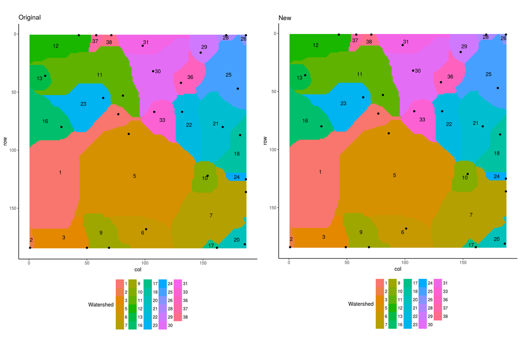

```r
c <- compare(ipit, orig_ipit)
```

```
## Shed area not the same, but within 3 cells
```

```
## Pit area not the same, but within 3 cells
```

```
## Pit Vol not the same, but within 1
```

```
## Varatio not the same, but within 5
```

```
## Pit seqno not all the same, but all within 1 cell
```

```
## Out elev not all the same, but within 0.01
```

```
## Out seqno not all the same, but all within 1 cell
```

- Pit and Shed areas off by a small amount
- Leads to small differences in pit volume and varatio

Original vs. New differences in Pit volume:

```
## # A tibble: 2 x 5
##   shedno shed_area pit_area pit_vol varatio
##    <int>     <int>    <int>   <dbl>   <dbl>
## 1     30      1953      316  70.552   36.12
## 2     36       641       89  10.684   16.67
```

```
## # A tibble: 2 x 5
##   shedno shed_area pit_area pit_vol varatio
##    <dbl>     <int>    <int>   <dbl>   <dbl>
## 1     30      1953      315  71.144   36.43
## 2     36       642       89  10.702   16.67
```

Original vs. New differences in Varatio

```
## # A tibble: 4 x 5
##   shedno shed_area pit_area pit_vol varatio
##    <int>     <int>    <int>   <dbl>   <dbl>
## 1     22      1075       78  16.592   15.43
## 2     25      1784      332 195.497  109.58
## 3     29       498       47   5.389   10.82
## 4     30      1953      316  70.552   36.12
```

```
## # A tibble: 4 x 5
##   shedno shed_area pit_area pit_vol varatio
##    <dbl>     <int>    <int>   <dbl>   <dbl>
## 1     22      1074       78  16.592   15.45
## 2     25      1783      332 195.497  109.64
## 3     29       499       47   5.389   10.80
## 4     30      1953      315  71.144   36.43
```

- small differences in exact pit location (off by one cell at most)
- small differences in exact overflow point

Original vs. New differences in flow out point (seqno/row/col)

```
## # A tibble: 4 x 7
##   shedno pour_elev pit_seqno out_seqno out_row out_col out_elev
##    <dbl>     <dbl>     <int>     <int>   <dbl>   <dbl>    <dbl>
## 1     16     6.418     14801     13312      72      35    6.391
## 2     17     8.432     34382     34199     183     165    8.427
## 3     22     3.317     12474     12654      68     125    3.292
## 4     38     3.364        71      1940      11      70    3.361
```

```
## # A tibble: 4 x 7
##   shedno pour_elev pit_seqno out_seqno out_row out_col out_elev
##    <int>     <dbl>     <int>     <int>   <int>   <int>    <dbl>
## 1     16     6.418     14801     13499      73      35    6.410
## 2     17     8.432     34383     34386     184     165    8.429
## 3     22     3.317     12474     12841      69     125    3.301
## 4     38     3.364        71      1941      11      71    3.363
```